# Data Wrangling (Data Preprocessing)

Practical assessment 2

Wing Hang Chan

26-May-022

## **Setup**

```r
suppressMessages(library(dplyr))
suppressMessages(library(kableExtra))
suppressMessages(library(lubridate))
library(magrittr)
library(MVN)
library(readr)
library(readxl)
library(outliers)
library(stringr)
```

## **Student names, numbers and percentage of contributions**

Group information

| Student name | Student number | Percentage of contribution |
| --- | --- | --- |
| Wing Hang, Chan | S3939713 | 100% |

## **Executive Summary**

Data set has been downloaded to the local machine and save to a directory which is near the R source code. The R code studio then has to locate the working directory with the data set saved.  
*read_csv* and *read_xlsx* functions are used to read the data set which are provided by readr and readxl library respectively. *merge* function is used for joining two data frames to meet the minimum requirement 1. Then, *as.factor* function is chosen for transforming a row data from character to ordered factors. as.*date* is also run for converting time to date for requirement 2-4. A function is created to replace value of 0 to na with *mutate* and *across* functions. *unique* is applied for checking the distinct ID. *mutate* is called to transform and create new columns. *is.na* function is used for checking na value in columns. Those functions are used to fulfill the requirement 5-7. *boxplot* function is used for plotting a visual graph to spot the outliers. MVN package is also applied for detecting outliers to meet requirement 9. *log*, *scale* and *hist* are used for normalization of data and showing a balanced chart which achieves requirement 9. Requirement 10 must be satisfy by importing the libraries for those functions.  
Finally, the step of pre-processing should be reshuffled. The separated dataset should be tidy up before they are being merged. It is because after merging, there may be more duplicated rows and processing time will be longer.

## **Data**

Found a rental properties collaboration data set from kaggle.com (kaggle.com 2020) The data set contains of 3 files, 2 csv files and 1 xlsx file.  
Attribute **event_type** in user_activity table can be referred to abttribute **Event type** in event_types. **item_id** in user_activity can be referred to another **item_id** in user_activity. They are not merged in step 1, as to eliminate duplication data for next few steps. Detail data description describes as below tables.

#### property.csv

| Name | Description | Type |
| --- | --- | --- |
| item_id | Unique property id | character(36) |
| deposit | Bond of the property | number |
| monthly_rent | Price of rent the property | number |
| district_uuid | Location area unique id | character(36) |
| room_qty | Number of rooms | number |
| unit_area | area of house | number |
| has_elevator | Property has elevator or not | boolean |
| building_floor_count | Number of units in same floor | number |
| unit_floor | nth floor of the house | number |
| has_storage_area | Property include storage location or not | boolean |
| property_age | Age of the property | number |

#### user_activity.csv

| Name | Description | Type |
| --- | --- | --- |
| item_id | Unique property id | character(36) |
| user_id | Unique user id | character(36) |
| event_type | Log of user activity occured in each process step | Factor of event type |
| create_timestamp | Timestamp of creating records | Datetime |

#### event_types.xlsx

| Name | Description | Type |
| --- | --- | --- |
| Step | Order of the series of events | number |
| Event type | Name of event | character |
| meaning | Description of event | character |

Ref: kaggle.com 2020, Rental Properties Collaboration Data, Möbius, data file, AODC Public Domain Dedication and Licence (PDDL), https://www.kaggle.com/datasets/arashnic/property-data

```r
getwd()
```

```
[1] "/Users/chello/Desktop/RMIT/Math2349 - Data Wrangling/pratical assessment 2"
```

```r
setwd('/Users/chello/Desktop/RMIT/Math2349 - Data Wrangling/pratical assessment 2')
property <- read_csv('data/property.csv')
usr_act <- read_csv('data/user_activity.csv')
evt_types <- read_excel('data/event_types.xlsx')

head(property)
```

| item_id | deposit | monthly_rent | district_uuid | room_qty | unit_area | has_elevator | building_floor_count | unit_floor | has_storage_area | property_age |
| --- | --- | --- | --- | --- | --- | --- | --- | --- | --- | --- |
| 91c0e569-bddd-4128-9720-2550bb85580e | 64800000 | 0 | 263682f6-d0cd-4569-aeec-e727b76b7665 | 1 | 42 | FALSE | 3 | 0 | TRUE | 23 |
| b00b7919-06be-4d26-98b8-1971787e1d46 | 72000000 | 4320000 | 97c9535e-3985-47ce-a84c-a962c838a76b | 2 | 116 | TRUE | NA | 1 | TRUE | 16 |
| 9eddb6bc-e424-4774-b55f-bfd54366d627 | 50400000 | 1440000 | b790f536-c274-4147-86e0-94d9b6d7352d | 1 | 74 | FALSE | 2 | 0 | TRUE | 19 |
| 12cf6b07-5d56-4126-94d2-ce9cbfe2214f | 36000000 | 864000 | 93d06676-4975-4cc5-919b-3a0c29c7ad43 | 1 | 60 | TRUE | NA | 2 | FALSE | 6 |
| 929eb20c-3694-46b2-b96c-91117b995d1b | 28800000 | 1296000 | 58e59fa9-9947-478f-9cef-bc6a2cbe49a9 | 1 | 45 | TRUE | NA | 1 | TRUE | 4 |
| 834d0738-9820-43bd-90b3-69e61e833201 | 122400000 | 0 | 93d06676-4975-4cc5-919b-3a0c29c7ad43 | 2 | 86 | TRUE | NA | 5 | FALSE | 5 |

```r
head(usr_act)
```

| item_id | user_id | event_type | create_timestamp |
| --- | --- | --- | --- |
| 00062bc5-2535-4b1e-bbcb-228526c990b8 | 182aa519-83a8-848f-84a1-8697046d84c2 | seen | 2020-02-03 15:47:25 |
| 00062bc5-2535-4b1e-bbcb-228526c990b8 | 189a081a-ae0f-499d-9092-01758d93fa7f | seen | 2020-02-04 20:19:31 |
| 00062bc5-2535-4b1e-bbcb-228526c990b8 | 189a081a-ae0f-499d-9092-01758d93fa7f | sent_catalog_link | 2020-02-04 20:19:00 |
| 00062bc5-2535-4b1e-bbcb-228526c990b8 | 189a081a-ae0f-499d-9092-01758d93fa7f | visit_request-canceled | 2020-02-04 20:54:31 |
| 00062bc5-2535-4b1e-bbcb-228526c990b8 | 189a081a-ae0f-499d-9092-01758d93fa7f | visit_request-new | 2020-02-04 20:20:15 |
| 00062bc5-2535-4b1e-bbcb-228526c990b8 | 18e0a74e-8418-854e-8a77-84aa7577d551 | seen_in_list | 2020-02-03 19:36:59 |

```r
head(evt_types)
```

| Step | Event type | meaning |
| --- | --- | --- |
| 1 | seen_in_list | Home impression on website |
| 2 | seen | Home view on Address website |
| 3 | suggest-new | Home link sent via text message, suggested by Address team |
| 4 | suggest_similar | Similar homes sent to tenant |
| 5 | sent_catalog_link | Home link sent via text message |
| 6 | visit_request-new | User requested to visit the home |

```r
# requirement 1
usr_act_detail <- merge(x=usr_act, y=evt_types,
                by.x = c("event_type"), by.y = c("Event type") )
head(usr_act_detail)
```

|  | event_type | item_id | user_id | create_timestamp | Step | meaning |
| --- | --- | --- | --- | --- | --- | --- |
| 1 | deal-success | 8e0e5341-5758-4209-bc39-02d1cb20c1e5 | d2208de5-19d2-49f1-a501-3a389e9f9e69 | 2020-02-09 17:30:12 | 18 | Successful rent |
| 2 | deal-success | 3376d4b2-36b7-4d0b-bc55-f189bbe6bb4f | dd0ea5f3-44a4-440d-aed1-e01560ead4d6 | 2020-02-10 20:16:47 | 18 | Successful rent |
| 3 | deal-success | 59b1416e-4206-4cb5-9bb8-9b2554db2b43 | 4a7308e7-a54f-4ef2-a39c-069988694fa3 | 2020-02-11 17:18:24 | 18 | Successful rent |
| 4 | deal-success | 57d9b528-3708-4c39-9e83-4f6eb25fdc26 | 58663c8d-5aa2-407a-8892-0146875ce67e | 2020-02-09 13:58:56 | 18 | Successful rent |
| 5 | deal-success | 74788b97-36b2-4e2b-b7b0-0b444676fcb5 | fee6c60a-c5ac-4fe7-aaf8-df7f59e959ad | 2020-02-12 21:51:18 | 18 | Successful rent |
| 6 | deal-success | 0b8b1b1f-0102-41c5-b7c6-8228f5d023f0 | f6aa23d5-9ae9-415d-98c5-13d3f08acc9a | 2020-02-12 22:14:08 | 18 | Successful rent |

```r
# Do not merge here to avoid duplicate values for next steps
# merged <- merge(x=property, y=usr_act, by = "item_id")
```

## **Understand**

```r
# requirement 2
c(evt_types['Event type'])
```

```
$`Event type`
 [1] "seen_in_list"             "seen"                     "suggest-new"
 [4] "suggest_similar"          "sent_catalog_link"        "visit_request-new"
 [7] "visit_request-canceled"   "visit-new"                "visit-canceled"
[10] "visit-unsuccess"          "visit-success"            "meeting_request-new"
[13] "meeting_request-canceled" "meeting-new"              "meeting-canceled"
[16] "meeting-unsuccess"        "meeting-success"          "deal-success"
```

```r
evt_types_lv = evt_types[['Event type']]

# requirement 3 & 4
usr_act_detail$event_type <-
  factor(usr_act_detail$event_type,
         levels = evt_types_lv,
         ordered = TRUE)
head(usr_act_detail)
```

|  | event_type | item_id | user_id | create_timestamp | Step | meaning |
| --- | --- | --- | --- | --- | --- | --- |
| 1 | deal-success | 8e0e5341-5758-4209-bc39-02d1cb20c1e5 | d2208de5-19d2-49f1-a501-3a389e9f9e69 | 2020-02-09 17:30:12 | 18 | Successful rent |
| 2 | deal-success | 3376d4b2-36b7-4d0b-bc55-f189bbe6bb4f | dd0ea5f3-44a4-440d-aed1-e01560ead4d6 | 2020-02-10 20:16:47 | 18 | Successful rent |
| 3 | deal-success | 59b1416e-4206-4cb5-9bb8-9b2554db2b43 | 4a7308e7-a54f-4ef2-a39c-069988694fa3 | 2020-02-11 17:18:24 | 18 | Successful rent |
| 4 | deal-success | 57d9b528-3708-4c39-9e83-4f6eb25fdc26 | 58663c8d-5aa2-407a-8892-0146875ce67e | 2020-02-09 13:58:56 | 18 | Successful rent |
| 5 | deal-success | 74788b97-36b2-4e2b-b7b0-0b444676fcb5 | fee6c60a-c5ac-4fe7-aaf8-df7f59e959ad | 2020-02-12 21:51:18 | 18 | Successful rent |
| 6 | deal-success | 0b8b1b1f-0102-41c5-b7c6-8228f5d023f0 | f6aa23d5-9ae9-415d-98c5-13d3f08acc9a | 2020-02-12 22:14:08 | 18 | Successful rent |

```r
str(usr_act_detail['event_type'])
```

```
'data.frame':   323893 obs. of  1 variable:
 $ event_type: Ord.factor w/ 18 levels "seen_in_list"<..: 18 18 18 18 18 18 18 18 18 18 ...
```

```r
# create a new column as create_date from create_timestamp
usr_act_detail$create_date <- as.Date(usr_act_detail$create_timestamp)
# another data type conversions done in section 4 for event_type
```

#### **Data information of usr_act_detail (event_types.xlsx)**

```r
typeof(usr_act_detail)
```

```
[1] "list"
```

```r
str(usr_act_detail)
```

```
'data.frame':   323893 obs. of  7 variables:
 $ event_type      : Ord.factor w/ 18 levels "seen_in_list"<..: 18 18 18 18 18 18 18 18 18 18 ...
 $ item_id         : chr  "8e0e5341-5758-4209-bc39-02d1cb20c1e5" "3376d4b2-36b7-4d0b-bc55-f189bbe6bb4f" "59b1416e-4206-4cb5-9bb8-9b2554db2b43" "57d9b528-3708-4c39-9e83-4f6eb25fdc26" ...
 $ user_id         : chr  "d2208de5-19d2-49f1-a501-3a389e9f9e69" "dd0ea5f3-44a4-440d-aed1-e01560ead4d6" "4a7308e7-a54f-4ef2-a39c-069988694fa3" "58663c8d-5aa2-407a-8892-0146875ce67e" ...
 $ create_timestamp: POSIXct, format: "2020-02-09 17:30:12" "2020-02-10 20:16:47" ...
 $ Step            : num  18 18 18 18 18 18 18 18 18 18 ...
 $ meaning         : chr  "Successful rent" "Successful rent" "Successful rent" "Successful rent" ...
 $ create_date     : Date, format: "2020-02-09" "2020-02-10" ...
```

```r
class(usr_act_detail)
```

```
[1] "data.frame"
```

```r
dim(usr_act_detail)
```

```
[1] 323893      7
```

#### **Data information of property (property.csv)**

```r
typeof(property)
```

```
[1] "list"
```

```r
str(property)
```

```
spec_tbl_df [4,930 × 11] (S3: spec_tbl_df/tbl_df/tbl/data.frame)
 $ item_id             : chr [1:4930] "91c0e569-bddd-4128-9720-2550bb85580e" "b00b7919-06be-4d26-98b8-1971787e1d46" "9eddb6bc-e424-4774-b55f-bfd54366d627" "12cf6b07-5d56-4126-94d2-ce9cbfe2214f" ...
 $ deposit             : num [1:4930] 64800000 72000000 50400000 36000000 28800000 ...
 $ monthly_rent        : num [1:4930] 0 4320000 1440000 864000 1296000 ...
 $ district_uuid       : chr [1:4930] "263682f6-d0cd-4569-aeec-e727b76b7665" "97c9535e-3985-47ce-a84c-a962c838a76b" "b790f536-c274-4147-86e0-94d9b6d7352d" "93d06676-4975-4cc5-919b-3a0c29c7ad43" ...
 $ room_qty            : num [1:4930] 1 2 1 1 1 2 1 1 1 1 ...
 $ unit_area           : num [1:4930] 42 116 74 60 45 86 58 68 68 42 ...
 $ has_elevator        : logi [1:4930] FALSE TRUE FALSE TRUE TRUE TRUE ...
 $ building_floor_count: num [1:4930] 3 NA 2 NA NA NA NA 3 2 4 ...
 $ unit_floor          : num [1:4930] 0 1 0 2 1 5 0 2 2 1 ...
 $ has_storage_area    : logi [1:4930] TRUE TRUE TRUE FALSE TRUE FALSE ...
 $ property_age        : num [1:4930] 23 16 19 6 4 5 25 18 27 0 ...
 - attr(*, "spec")=
  .. cols(
  ..   item_id = col_character(),
  ..   deposit = col_double(),
  ..   monthly_rent = col_double(),
  ..   district_uuid = col_character(),
  ..   room_qty = col_double(),
  ..   unit_area = col_double(),
  ..   has_elevator = col_logical(),
  ..   building_floor_count = col_double(),
  ..   unit_floor = col_double(),
  ..   has_storage_area = col_logical(),
  ..   property_age = col_double()
  .. )
 - attr(*, "problems")=<externalptr>
```

```r
class(property)
```

```
[1] "spec_tbl_df" "tbl_df"      "tbl"         "data.frame"
```

```r
dim(property)
```

```
[1] 4930   11
```

#### **Data information of usr_act (user_activity.csv)**

```r
typeof(usr_act)
```

```
[1] "list"
```

```r
str(usr_act)
```

```
spec_tbl_df [323,893 × 4] (S3: spec_tbl_df/tbl_df/tbl/data.frame)
 $ item_id         : chr [1:323893] "00062bc5-2535-4b1e-bbcb-228526c990b8" "00062bc5-2535-4b1e-bbcb-228526c990b8" "00062bc5-2535-4b1e-bbcb-228526c990b8" "00062bc5-2535-4b1e-bbcb-228526c990b8" ...
 $ user_id         : chr [1:323893] "182aa519-83a8-848f-84a1-8697046d84c2" "189a081a-ae0f-499d-9092-01758d93fa7f" "189a081a-ae0f-499d-9092-01758d93fa7f" "189a081a-ae0f-499d-9092-01758d93fa7f" ...
 $ event_type      : chr [1:323893] "seen" "seen" "sent_catalog_link" "visit_request-canceled" ...
 $ create_timestamp: POSIXct[1:323893], format: "2020-02-03 15:47:25" "2020-02-04 20:19:31" ...
 - attr(*, "spec")=
  .. cols(
  ..   item_id = col_character(),
  ..   user_id = col_character(),
  ..   event_type = col_character(),
  ..   create_timestamp = col_datetime(format = "")
  .. )
 - attr(*, "problems")=<externalptr>
```

```r
class(usr_act)
```

```
[1] "spec_tbl_df" "tbl_df"      "tbl"         "data.frame"
```

```r
dim(usr_act)
```

```
[1] 323893      4
```

#### **Data information of evt_types (event_types.xlsx)**

```r
typeof(evt_types)
```

```
[1] "list"
```

```r
str(evt_types)
```

```
tibble [18 × 3] (S3: tbl_df/tbl/data.frame)
 $ Step      : num [1:18] 1 2 3 4 5 6 7 8 9 10 ...
 $ Event type: chr [1:18] "seen_in_list" "seen" "suggest-new" "suggest_similar" ...
 $ meaning   : chr [1:18] "Home impression on website" "Home view on Address website" "Home link sent via text message, suggested by Address team" "Similar homes sent to tenant" ...
```

```r
class(evt_types)
```

```
[1] "tbl_df"     "tbl"        "data.frame"
```

```r
dim(evt_types)
```

```
[1] 18  3
```

## **Tidy & Manipulate Data I**

```r
replace_0_na <- function(x) {
  ifelse(x == 0, NA, x)
}

property <- property %>%
  mutate(across(
    c(
      'deposit',
      'monthly_rent',
      'unit_area',
      'building_floor_count'
    ),
    replace_0_na
  ))


# unit floor 225 outliers

# check uniqueness for item_id
length(unique(property$item_id)) == dim(property)[1]
```

```
[1] TRUE
```

```r
length(unique(property$district_uuid)) == dim(property)[1]
```

```
[1] FALSE
```

```r
length(unique(usr_act_detail$uesr_id)) == dim(usr_act_detail)[1]
```

```
[1] FALSE
```

```r
# unit floor -2 -1 0 may represent underground or ground floor
```

## **Tidy & Manipulate Data II**

```r
property <- property %>%
  mutate(
    weekly_rent = monthly_rent * 12 / 52,
  )

property <- property %>%
  mutate(
    deposit_rent_area_ratio = deposit / (monthly_rent * unit_area),
  )
```

## **Scan I**

```r
sum(is.na(property$deposit))
```

```
[1] 13
```

```r
sum(is.na(property$monthly_rent))
```

```
[1] 1846
```

```r
sum(is.na(property$room_qty))
```

```
[1] 3
```

```r
sum(is.na(property$unit_area))
```

```
[1] 2
```

```r
sum(is.na(property$has_elevator))
```

```
[1] 17
```

```r
sum(is.na(property$building_floor_count))
```

```
[1] 1650
```

```r
sum(is.na(property$unit_floor))
```

```
[1] 37
```

```r
sum(is.na(property$has_storage_area))
```

```
[1] 10
```

```r
sum(is.na(property$property_age))
```

```
[1] 4
```

```r
district_deposit_mean <- property %>%
  group_by(district_uuid) %>%
  summarise(across(deposit, mean, .names="district_deposit_mean", na.rm = TRUE))

property <- merge(x=property, y=district_deposit_mean,
                  by = "district_uuid" )

property <- property %>%
  mutate(cleaned_deposit = ifelse(
    is.na(monthly_rent),
    `district_deposit_mean`,
    `monthly_rent`
  ))

district_monthly_rent_mean <- property %>%
  group_by(district_uuid) %>%
  summarise(across(monthly_rent,
                   mean,
                   .names = "district_monthly_rent_mean",
                   na.rm = TRUE))

property <- merge(x = property, y = district_monthly_rent_mean,
                  by = "district_uuid")

property <- property %>%
  mutate(cleaned_monthly_rent = ifelse(
    is.na(monthly_rent),
    `district_monthly_rent_mean`,
    `monthly_rent`
  ))
```

## **Scan II**

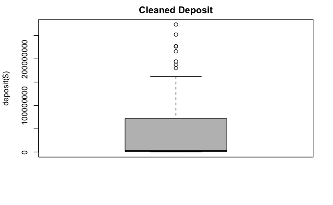

```r
options(scipen = 999)
property$cleaned_deposit %>%
  boxplot(main="Cleaned Deposit", ylab="deposit($)", col = "grey")
```

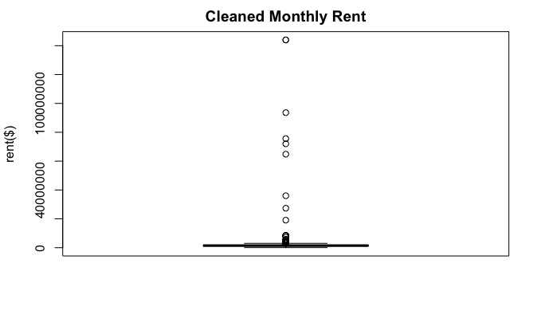

```r
property$cleaned_monthly_rent %>%
  boxplot(main="Cleaned Monthly Rent", ylab="rent($)", col = "grey")
```

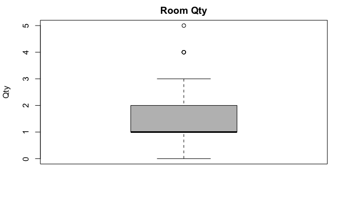

```r
property$room_qty %>%
  boxplot(main="Room Qty", ylab="Qty", col = "grey")
```

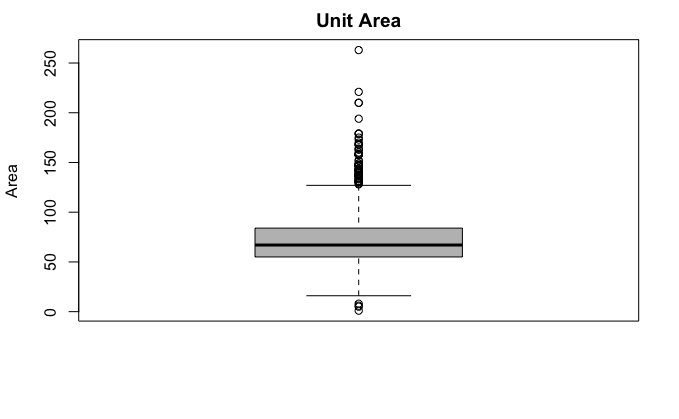

```r
property$unit_area %>%
  boxplot(main="Unit Area", ylab="Area", col = "grey")
```

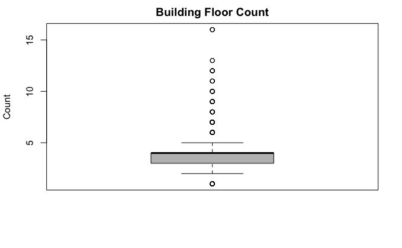

```r
property$building_floor_count %>%
  boxplot(main="Building Floor Count", ylab="Count", col = "grey")
```

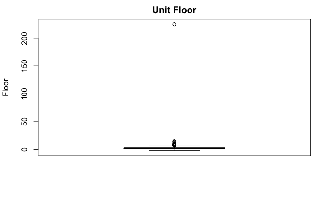

```r
property$unit_floor %>%
  boxplot(main="Unit Floor", ylab="Floor", col = "grey")
```

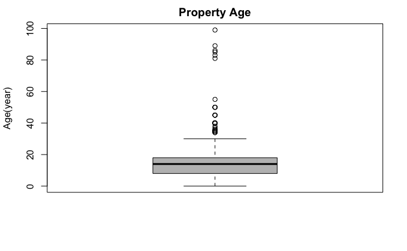

```r
property$property_age %>%
  boxplot(main="Property Age", ylab="Age(year)", col = "grey")
```

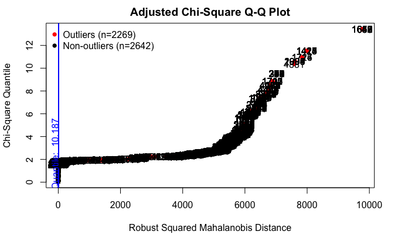

```r
p <- property %>% select('cleaned_deposit',
                      'cleaned_monthly_rent',
                      'district_uuid') %>% group_by(district_uuid)

results <-
  mvn(
    data = property %>% select('cleaned_deposit', 'cleaned_monthly_rent'),
    multivariateOutlierMethod = "adj",
    showOutliers = TRUE,
    bc = TRUE, bcType="optimal"
  )
```

```r
results$multivariateOutliers
```

|  | Observation | Mahalanobis Distance | Outlier |
| --- | --- | --- | --- |
| 1638 | 1638 | 9770.335 | TRUE |
| 1639 | 1639 | 9770.335 | TRUE |
| 1640 | 1640 | 9770.335 | TRUE |
| 1642 | 1642 | 9770.335 | TRUE |
| 1643 | 1643 | 9770.335 | TRUE |
| 1645 | 1645 | 9770.335 | TRUE |
| 1647 | 1647 | 9770.335 | TRUE |
| 1648 | 1648 | 9770.335 | TRUE |
| 1649 | 1649 | 9770.335 | TRUE |
| 1651 | 1651 | 9770.335 | TRUE |

[output cut: 990 more lines]

```r
NA
```

There are 7 numeric attribute values. Using box spot can be spotted. They are *cleaned_deposit, cleaned_monthly_rent, room_qty, unit_area, building_floor_count, unit_floor and property_age*. Those outliers cannot be deleted, as there may be references for user activity tables. They cannot be replaced by mean value as well, because those values have their own meaning and the mean tells nothing to those attributes. Therefore, no action can be applied for those outliers.  
There are so many outliners for *clean_deposit* and *clean_monthly_rent* because they are in different districts. There may be a chance of higher value with the city districts. Also the higher unit area, the higher the deposit.

## **Transform**

```r
scale_df1 <- scale(property['cleaned_deposit'], center = TRUE, scale = TRUE)
head(scale_df1)
```

```
     cleaned_deposit
[1,]       1.2010999
[2,]       1.2010999
[3,]      -0.7012336
[4,]      -0.7336500
[5,]      -0.7353562
[6,]      -0.6927029
```

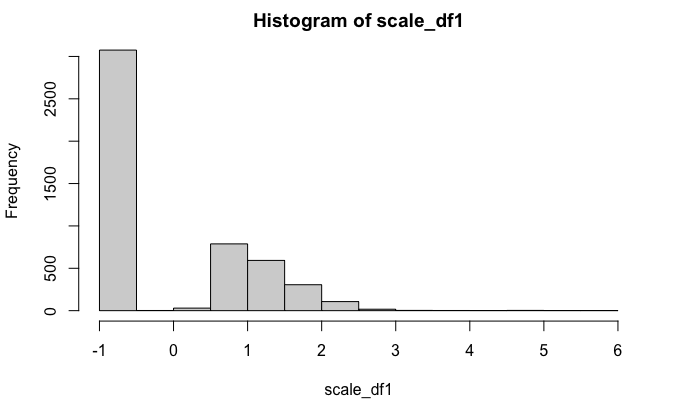

```r
hist(scale_df1)
```

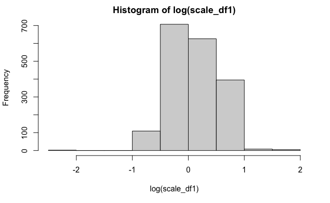

```r
hist(log(scale_df1))
```